# Deer Creek

Sadie Gill, Mark Tompkins

June 2021

## Instream Spawning and Rearing Habitat

**Data Source:** [FlowWest 2021](https://cvpiahabitat-r-package.s3.us-west-2.amazonaws.com/cvpia-sit-model-inputs/DeerCreek_2Dmodel_FlowWest_Final.pdf)

A flow to suitable area relationship was modeled using depth and velocity suitability ranges applied to HEC-RAS 2-dimensional hydraulic model output for the instream spawning habitat of Fall Run Chinook Salmon, Late-Fall Run Chinook Salmon and the instream rearing habitat of Fall Run Chinook Salmon, Late-Fall Run Chinook Salmon, Spring Run Chinook Salmon, and Steelhead, as well as fry habitat for Fall Run Chinook Salmon, Late-Fall Run Chinook Salmon, Spring Run Chinook Salmon, and Steelhead. Spring Run Chinook and Steelhead spawning habitat were [calculated with a relationship between flow and mean weighted usable area from watersheds in the region with modeled habitat](http://cvpia-habitat-docs-markdown.s3-website-us-west-2.amazonaws.com/watershed/Regional_Approximation.html).

Suitable ranges for Deer Creek were defined using the following sources:

- Fall Run & Late-Fall Run Spawning - Clear Creek Fall Run Suitability Criteria (Gard 2019)
- All Species Juvenile Instream Rearing - Clear Creek Fall Run Suitability Criteria (Gard 2019)
- All Species Juvenile Floodplain Rearing - CBEC 2019
- Fall, Spring & Late-Fall Fry Rearing - Battle Creek Fall Run Suitability Criteria (Gard 2019)
- Steelhead Fry Rearing - Battle Creek Steelhead Suitability Criteria (Gard 2019)

Data from Gard 2019 can be downloaded [here](https://cvpia-documents.s3.us-west-1.amazonaws.com/HSC.xlsx).

The depth and velocity ranges for species and life-stage combinations are listed in the following table.

| **Species** | **Lifestage** | **Location** | **Suitable Depth Range (feet)** | **Suitable Velocity Range (feet)** |  |
| --- | --- | --- | --- | --- | --- |
| Fall Run Chinook, Late-Fall Run Chinook | Adult Spawning | Instream | 0.41 - 6.69 | 0.09 - 6.30 |  |
| Fall Run Chinook, Late-Fall Run Chinook | Juvenile Rearing | Instream | 0.41 - 5.31 | 0.00 - 3.07 |  |
| Spring Run Chinook, Steelhead | Juvenile Rearing | Instream | 0.21 - 5.59 | 0.00 - 5.54 |  |
| Fall Run Chinook, Late-Fall Run Chinook, Spring Run Chinook, Steelhead | Juvenile Rearing | Floodplain | 0.50 - 5.20 | 0.00 - 4.00 |  |
| Fall Run Chinook, Late-Fall Run Chinook, Spring Run Chinook | Fry | Instream | 0.05 - 3.45 | 0 - 1.82 |  |
| Steelhead | Fry | Instream | 0.09 - 4 | 0.09 - 3.6 |  |

### Spawning Data

Header Descriptions: flow_cfs = flow in cubic feet per second, FR_spawn_sqm = Fall Run Chinook Spawning Area (square meters), LFR_spawn_sqm = Late-Fall Run Chinook Spawning Area (square meters), watershed = section of stream modeled for CVPIA SDM

| flow_cfs | FR_spawn_sqm | LFR_spawn_sqm |
| --- | --- | --- |
| 100 | 65720.83 | 65720.83 |
| 250 | 82800.52 | 82800.52 |
| 300 | 86789.41 | 86789.41 |
| 400 | 92295.97 | 92295.97 |
| 500 | 95754.20 | 95754.20 |

*… with 13 more rows*

### Rearing Data

Header Descriptions: flow_cfs = flow in cubic feet per second, FR_juv_sqm = Fall Run Chinook Juvenile Area (square meters), LFR_juv_sqm = Late-Fall Run Chinook Spawning Area (square meters), SR_juv_sqm = Spring Run Chinook Juvenile Area (square meters), ST_juv_sqm = Steelhead Juvenile Area (square meters), FR_fry_sqm = Fall Run Chinook Juvenile Area (square meters), LFR_fry_sqm = Late-Fall Run Chinook Spawning Area (square meters), SR_fry_sqm = Spring Run Chinook Juvenile Area (square meters), ST_fry_sqm = Steelhead Juvenile Area (square meters)

| flow_cfs | FR_juv_sqm | LFR_juv_sqm | SR_juv_sqm | ST_juv_sqm | FR_fry_sqm | LFR_fry_sqm | SR_fry_sqm | ST_fry_sqm |
| --- | --- | --- | --- | --- | --- | --- | --- | --- |
| 100 | 286756.1 | 286756.1 | 418029.9 | 418029.9 | 236918.4 | 236918.4 | 306310.4 | 426783.4 |
| 250 | 322257.7 | 322257.7 | 527637.3 | 527637.3 | 171301.2 | 171301.2 | 221474.4 | 501108.5 |
| 300 | 329779.9 | 329779.9 | 561604.6 | 561604.6 | 167021.0 | 167021.0 | 215940.5 | 517413.7 |
| 400 | 329927.4 | 329927.4 | 613082.1 | 613082.1 | 159890.8 | 159890.8 | 206722.0 | 529421.8 |
| 500 | 323999.9 | 323999.9 | 653528.4 | 653528.4 | 160461.6 | 160461.6 | 207460.0 | 517640.5 |

*… with 13 more rows*

### Spawning Habitat Area

The following plot shows the suitable spawning habitat in acres for Fall Run and Late-Fall Run Chinook.

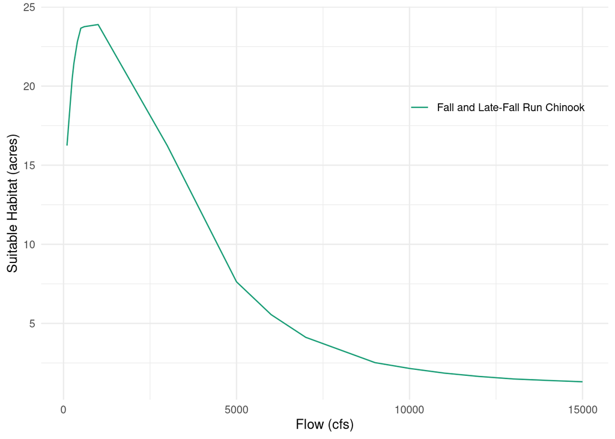

### Fry Rearing Habitat Area

The following plot shows the suitable fry habitat in acres for Fall Run Chinook, Late-Fall Run Chinook, Spring Run Chinook and Steelhead.

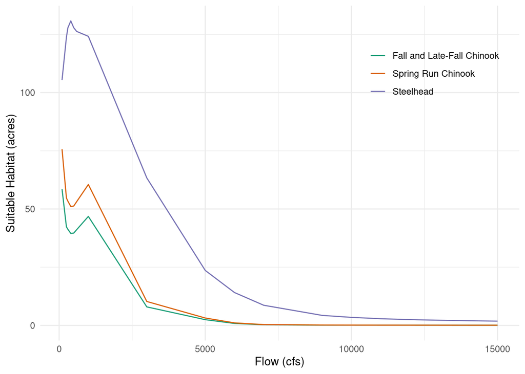

### Juvenile Rearing Habitat Area

The following plot shows the suitable rearing habitat in acres for Fall Run Chinook, Late-Fall Run Chinook, Spring Run Chinook and Steelhead.

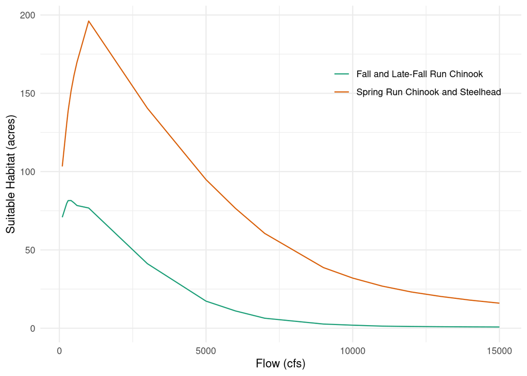

## Floodplain Rearing Habitat

**Data Source:** [Calcuated using a flow to area relationship modeled using HEC-RAS (FlowWest 2021)](https://cvpiahabitat-r-package.s3.us-west-2.amazonaws.com/cvpia-sit-model-inputs/DeerCreek_2Dmodel_FlowWest_Final.pdf)

### Fall Run and Late-Fall Run

The entire mapped rearing extent of 12.2 miles was modeled using Lower Deer Creek Flood and Ecosystem Improvement Project HEC-RAS Hydrodynamic model. An active channel area of 58.7 acres, estimated through remote sensing analysis, was subtracted from total inundated area to obtain inundated floodplain area.

### Spring Run and Steelhead

A 12.2 mile portion of the entire mapped rearing extent of 47.9 miles was modeled using Lower Deer Creek Flood and Ecosystem Improvement Project HEC-RAS Hydrodynamic model. Of the entire mapped rearing extent, 12.2 miles were classified as low gradient and 35.7 miles were classified as high gradient based on a geomorphic analysis of long profile slopes and valley widths. The floodplain area per unit length was determined for the modeled extent and used to approximate areas for the non-modeled extent. The area per unit length was scaled by a factor of 0.1 for the high gradient extent. There was no scaling factor applied to the low gradient extent.

## Floodplain Data

The areas represent total suitable rearing area in acres.

Header Descriptions: flow_cfs = flow in cubic feet per second, FR_floodplain_acres = Fall Run Chinook floodplain acres, SR_floodplain_acres = Spring Run Chinook floodplain acres, ST_floodplain_acres = Steelhead floodplain acres, watershed = section of stream modeled for CVPIA SDM

| flow_cfs | FR_floodplain_acres | LFR_floodplain_acres | SR_floodplain_acres | ST_floodplain_acres | watershed |
| --- | --- | --- | --- | --- | --- |
| 900 | 0.000000 | 0.000000 | 0.000000 | 0.000000 | Deer Creek |
| 1000 | 5.960422 | 5.960422 | 7.706198 | 7.706198 | Deer Creek |
| 3000 | 85.216162 | 85.216162 | 110.175510 | 110.175510 | Deer Creek |
| 5000 | 146.270983 | 146.270983 | 189.112954 | 189.112954 | Deer Creek |
| 6000 | 167.836639 | 167.836639 | 216.995074 | 216.995074 | Deer Creek |

*… with 8 more rows*

## Floodplain Plot

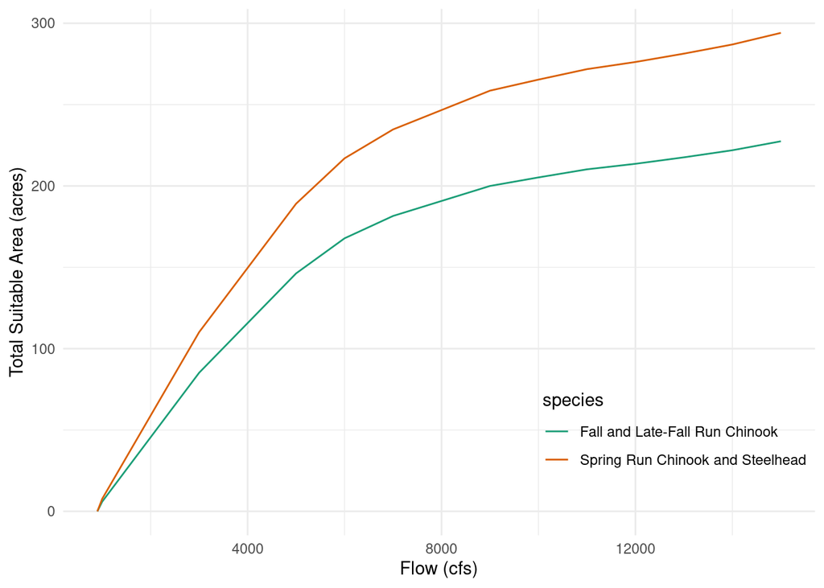